# Week 10 - Weekend Homework

```r
library(tidyverse)
library(tidyverse)
library(modelr)
library(GGally)
library(ggfortify)
```

```r
red_wine <- read_csv("data/wine_quality_red.csv")
white_wine <- read_csv("data/wine_quality_white.csv")
```

```r
head(red_wine)
```

| wine_id | fixed_acidity | volatile_acidity | citric_acid | residual_sugar | chlorides | free_sulfur_dioxide | total_sulfur_dioxide | density | p_h | sulphates | alcohol | quality | region |
| --- | --- | --- | --- | --- | --- | --- | --- | --- | --- | --- | --- | --- | --- |
| 1 | 7.4 | 0.70 | 0.00 | 1.9 | 0.076 | 11 | 34 | 0.9978 | 3.51 | 0.56 | 9.4 | 4.66 | Australia |
| 2 | 7.8 | 0.88 | 0.00 | 2.6 | 0.098 | 25 | 67 | 0.9968 | 3.20 | 0.68 | 9.8 | 4.82 | Spain |
| 3 | 7.8 | 0.76 | 0.04 | 2.3 | 0.092 | 15 | 54 | 0.9970 | 3.26 | 0.65 | 9.8 | 4.91 | Spain |
| 4 | 11.2 | 0.28 | 0.56 | 1.9 | 0.075 | 17 | 60 | 0.9980 | 3.16 | 0.58 | 9.8 | 5.96 | Australia |
| 5 | 7.4 | 0.70 | 0.00 | 1.9 | 0.076 | 11 | 34 | 0.9978 | 3.51 | 0.56 | 9.4 | 5.42 | Italy |
| 6 | 7.4 | 0.66 | 0.00 | 1.8 | 0.075 | 13 | 40 | 0.9978 | 3.51 | 0.56 | 9.4 | 4.78 | Italy |

```r
head(white_wine)
```

| wine_id | fixed_acidity | volatile_acidity | citric_acid | residual_sugar | chlorides | free_sulfur_dioxide | total_sulfur_dioxide | density | p_h | sulphates | alcohol | quality | region |
| --- | --- | --- | --- | --- | --- | --- | --- | --- | --- | --- | --- | --- | --- |
| 1 | 7.0 | 0.27 | 0.36 | 20.7 | 0.045 | 45 | 170 | 1.0010 | 3.00 | 0.45 | 8.8 | 5.92 | Australia |
| 2 | 6.3 | 0.30 | 0.34 | 1.6 | 0.049 | 14 | 132 | 0.9940 | 3.30 | 0.49 | 9.5 | 6.06 | Australia |
| 3 | 8.1 | 0.28 | 0.40 | 6.9 | 0.050 | 30 | 97 | 0.9951 | 3.26 | 0.44 | 10.1 | 6.25 | Spain |
| 4 | 7.2 | 0.23 | 0.32 | 8.5 | 0.058 | 47 | 186 | 0.9956 | 3.19 | 0.40 | 9.9 | 6.38 | Spain |
| 5 | 7.2 | 0.23 | 0.32 | 8.5 | 0.058 | 47 | 186 | 0.9956 | 3.19 | 0.40 | 9.9 | 6.35 | USA |
| 6 | 8.1 | 0.28 | 0.40 | 6.9 | 0.050 | 30 | 97 | 0.9951 | 3.26 | 0.44 | 10.1 | 5.82 | Italy |

split into some groups to make the ggpair plot readable “The classes are ordered and not balanced (e.g. there are many more normal wines than excellent or poor ones).”

# IMPORTANT: I don’t know anything about Wine

```r
group_1 <- white_wine %>%
  select(fixed_acidity:chlorides, quality)

group_2 <- white_wine %>%
  select(free_sulfur_dioxide:region)
```

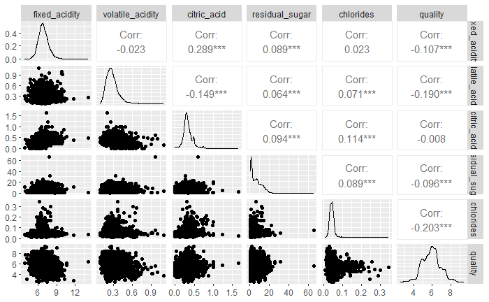

```r
group_1 %>%
  ggpairs()
```

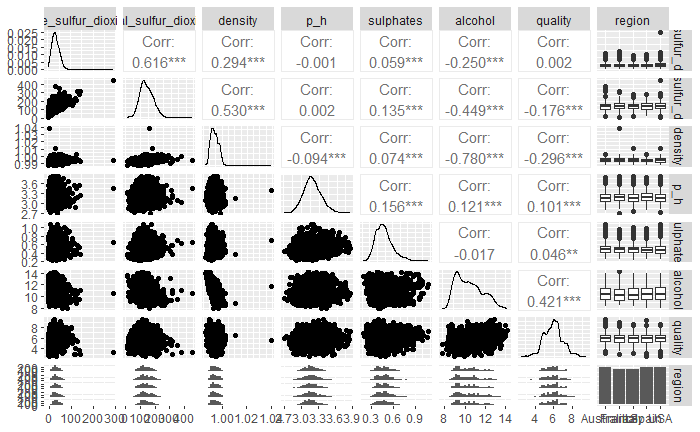

```r
group_2 %>%
  ggpairs()
```

group_1: chlorides and volatile_acidity might matter group_2: Region might make a difference, as might alcohol.

```r
white_wine %>%
  skimr::skim()
```

```
── Data Summary ────────────────────────
                           Values
Name                       Piped data
Number of rows             4898
Number of columns          14
_______________________
Column type frequency:
  character                1
  numeric                  13
________________________
Group variables            None
```

|  | skim_variable | n_missing | complete_rate | min | max | empty | n_unique | whitespace |
| --- | --- | --- | --- | --- | --- | --- | --- | --- |
| 1 | region | 0 | 1 | 3 | 9 | 0 | 5 | 0 |

|  | skim_variable | n_missing | complete_rate | mean | sd | p0 | p25 | p50 | p75 | p100 | hist |
| --- | --- | --- | --- | --- | --- | --- | --- | --- | --- | --- | --- |
| 1 | wine_id | 0 | 1 | 2.449500e+03 | 1.414075e+03 | 1.00000 | 1225.2500000 | 2449.50000 | 3673.7500 | 4898.00000 | ▇▇▇▇▇ |
| 2 | fixed_acidity | 0 | 1 | 6.854788e+00 | 8.438682e-01 | 3.80000 | 6.3000000 | 6.80000 | 7.3000 | 14.20000 | ▁▇▁▁▁ |
| 3 | volatile_acidity | 0 | 1 | 2.782411e-01 | 1.007945e-01 | 0.08000 | 0.2100000 | 0.26000 | 0.3200 | 1.10000 | ▇▅▁▁▁ |
| 4 | citric_acid | 0 | 1 | 3.341915e-01 | 1.210198e-01 | 0.00000 | 0.2700000 | 0.32000 | 0.3900 | 1.66000 | ▇▆▁▁▁ |
| 5 | residual_sugar | 0 | 1 | 6.391415e+00 | 5.072058e+00 | 0.60000 | 1.7000000 | 5.20000 | 9.9000 | 65.80000 | ▇▁▁▁▁ |
| 6 | chlorides | 0 | 1 | 4.577236e-02 | 2.184797e-02 | 0.00900 | 0.0360000 | 0.04300 | 0.0500 | 0.34600 | ▇▁▁▁▁ |
| 7 | free_sulfur_dioxide | 0 | 1 | 3.530808e+01 | 1.700714e+01 | 2.00000 | 23.0000000 | 34.00000 | 46.0000 | 289.00000 | ▇▁▁▁▁ |
| 8 | total_sulfur_dioxide | 0 | 1 | 1.383607e+02 | 4.249806e+01 | 9.00000 | 108.0000000 | 134.00000 | 167.0000 | 440.00000 | ▂▇▂▁▁ |
| 9 | density | 0 | 1 | 9.940274e-01 | 2.990907e-03 | 0.98711 | 0.9917225 | 0.99374 | 0.9961 | 1.03898 | ▇▂▁▁▁ |
| 10 | p_h | 0 | 1 | 3.188267e+00 | 1.510006e-01 | 2.72000 | 3.0900000 | 3.18000 | 3.2800 | 3.82000 | ▁▇▇▂▁ |

[output cut: 3 more lines]

```r
# lets try taking the log of the skewed things
white_wine_alt <- white_wine %>%
  select(!c(wine_id, fixed_acidity, density, p_h, sulphates, alcohol, quality, region)) %>%
  mutate(across(everything(), log)) %>%
  rename_with(~ paste0("log_", .x)) %>%
  bind_cols(white_wine)

group_3 <- white_wine_alt %>%
  select(starts_with("log_"), quality)
```

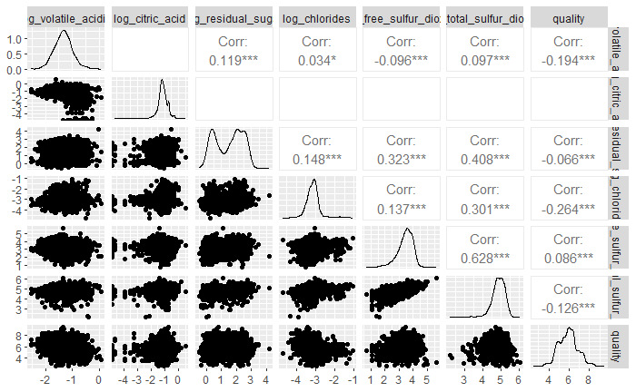

```r
group_3 %>%
  ggpairs()
```

```r
# Why is log_citric_acid broken

group_3 %>%
  select(log_citric_acid) %>%
  arrange(desc(log_citric_acid)) %>%
  slice_tail(n = 10)
```

| log_citric_acid |
| --- |
| -Inf |
| -Inf |
| -Inf |
| -Inf |
| -Inf |
| -Inf |
| -Inf |
| -Inf |
| -Inf |
| -Inf |

```r
# oh
```

```r
group_3 <- group_3 %>%
  select(!log_citric_acid)
```

Break down region into europe or not europe to see if that matters

```r
white_wine %>%
  distinct(region)
```

| region |
| --- |
| Australia |
| Spain |
| USA |
| Italy |
| France |

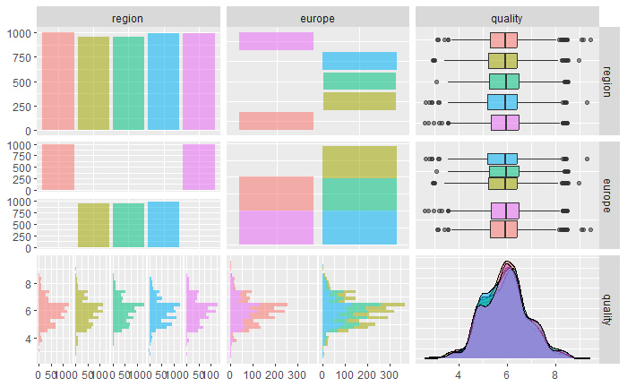

```r
white_wine_alt <- white_wine_alt %>%
  mutate(europe = case_when(
    region == "Australia" ~ FALSE,
    region == "USA" ~ FALSE,
    TRUE ~ TRUE
    ))

white_wine_alt %>%
  select(region, europe, quality) %>%
  ggpairs(aes(colour = region, alpha = 0.5))
```

Maybe it doesnt actually matter, but i’ll try anyway

what about sweetness?

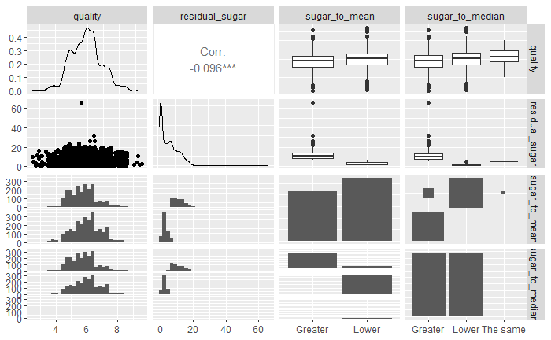

```r
white_wine_alt <- white_wine_alt %>%
  # select(residual_sugar, quality) %>%
  mutate(median_sugar = median(residual_sugar),
         mean_sugar = mean(residual_sugar),
         sugar_to_mean = case_when(
           residual_sugar > mean_sugar ~ "Greater",
           residual_sugar == mean_sugar ~ "The same",
           TRUE ~ "Lower"),
         sugar_to_median = case_when(
           residual_sugar > median_sugar ~ "Greater",
           residual_sugar == median_sugar ~ "The same",
           TRUE ~ "Lower")
         ) %>%
  select(!c(mean_sugar, median_sugar))


white_wine_alt %>%
  select(quality, residual_sugar, sugar_to_mean, sugar_to_median) %>%
   ggpairs()
```

Looks like being more or less sugary than the average makes a sort of difference

```r
model_1a <- lm(
  formula = quality ~ alcohol,
  data = white_wine_alt
)

summary(model_1a)
```

```
Call:
lm(formula = quality ~ alcohol, data = white_wine_alt)

Residuals:
    Min      1Q  Median      3Q     Max
-3.5247 -0.5623 -0.0207  0.5432  3.2832

Coefficients:
            Estimate Std. Error t value Pr(>|t|)
(Intercept) 2.523661   0.104913   24.05   <2e-16 ***
alcohol     0.321456   0.009911   32.44   <2e-16 ***
---
Signif. codes:  0 ‘***’ 0.001 ‘**’ 0.01 ‘*’ 0.05 ‘.’ 0.1 ‘ ’ 1

Residual standard error: 0.8535 on 4896 degrees of freedom
Multiple R-squared:  0.1769,    Adjusted R-squared:  0.1767
F-statistic:  1052 on 1 and 4896 DF,  p-value: < 2.2e-16
```

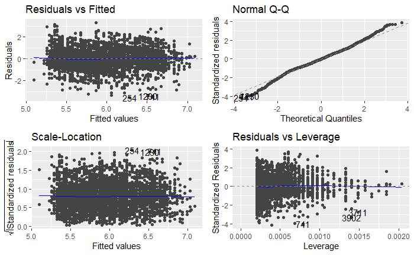

```r
autoplot(model_1a)
```

```r
model_1b <- lm(
  formula = quality ~ residual_sugar,
  data = white_wine_alt
)

model_1b_log <- lm(
  formula = quality ~ log_residual_sugar,
  data = white_wine_alt
)

model_1b_mean <- lm(
  formula = quality ~ sugar_to_mean,
  data = white_wine_alt
)

summary(model_1b)
```

```
Call:
lm(formula = quality ~ residual_sugar, data = white_wine_alt)

Residuals:
    Min      1Q  Median      3Q     Max
-3.3354 -0.6553  0.0134  0.5430  3.4620

Coefficients:
                Estimate Std. Error t value Pr(>|t|)
(Intercept)     6.017114   0.021525 279.541  < 2e-16 ***
residual_sugar -0.017771   0.002638  -6.736 1.82e-11 ***
---
Signif. codes:  0 ‘***’ 0.001 ‘**’ 0.01 ‘*’ 0.05 ‘.’ 0.1 ‘ ’ 1

Residual standard error: 0.9364 on 4896 degrees of freedom
Multiple R-squared:  0.009182,  Adjusted R-squared:  0.00898
F-statistic: 45.37 on 1 and 4896 DF,  p-value: 1.816e-11
```

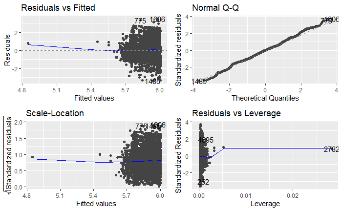

```r
autoplot(model_1b)
```

```r
summary(model_1b_log)
```

```
Call:
lm(formula = quality ~ log_residual_sugar, data = white_wine_alt)

Residuals:
    Min      1Q  Median      3Q     Max
-3.3005 -0.6657  0.0129  0.5452  3.4896

Coefficients:
                   Estimate Std. Error t value Pr(>|t|)
(Intercept)         6.00371    0.02538 236.524  < 2e-16 ***
log_residual_sugar -0.06764    0.01455  -4.648 3.44e-06 ***
---
Signif. codes:  0 ‘***’ 0.001 ‘**’ 0.01 ‘*’ 0.05 ‘.’ 0.1 ‘ ’ 1

Residual standard error: 0.9386 on 4896 degrees of freedom
Multiple R-squared:  0.004394,  Adjusted R-squared:  0.00419
F-statistic: 21.61 on 1 and 4896 DF,  p-value: 3.435e-06
```

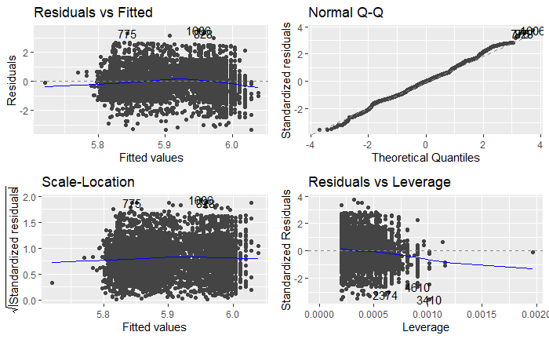

```r
autoplot(model_1b_log)
```

```r
summary(model_1b_mean)
```

```
Call:
lm(formula = quality ~ sugar_to_mean, data = white_wine_alt)

Residuals:
    Min      1Q  Median      3Q     Max
-3.4036 -0.6436  0.0148  0.5715  3.4364

Coefficients:
                   Estimate Std. Error t value Pr(>|t|)
(Intercept)         5.77683    0.02009 287.539   <2e-16 ***
sugar_to_meanLower  0.22675    0.02688   8.437   <2e-16 ***
---
Signif. codes:  0 ‘***’ 0.001 ‘**’ 0.01 ‘*’ 0.05 ‘.’ 0.1 ‘ ’ 1

Residual standard error: 0.9339 on 4896 degrees of freedom
Multiple R-squared:  0.01433,   Adjusted R-squared:  0.01413
F-statistic: 71.18 on 1 and 4896 DF,  p-value: < 2.2e-16
```

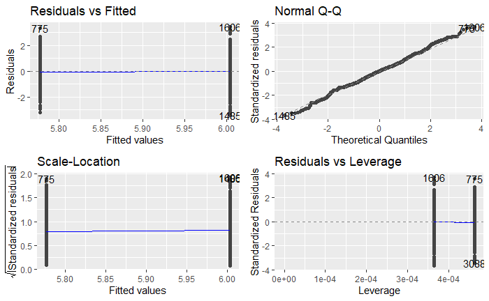

```r
autoplot(model_1b_mean)
```

```r
# Sweetness of a wine compared to average might make a difference
```

```r
model_1c <- lm(
  formula = quality ~ region,
  data = white_wine_alt
)

model_1c_alt <- lm(
  formula = quality ~ europe,
  data = white_wine_alt
)

summary(model_1c)
```

```
Call:
lm(formula = quality ~ region, data = white_wine_alt)

Residuals:
    Min      1Q  Median      3Q     Max
-3.3762 -0.6640  0.0238  0.5297  3.5559

Coefficients:
              Estimate Std. Error t value Pr(>|t|)
(Intercept)   5.884102   0.029707 198.070   <2e-16 ***
regionFrance -0.015053   0.042503  -0.354    0.723
regionItaly   0.069856   0.042526   1.643    0.101
regionSpain  -0.009016   0.042150  -0.214    0.831
regionUSA     0.052049   0.042086   1.237    0.216
---
Signif. codes:  0 ‘***’ 0.001 ‘**’ 0.01 ‘*’ 0.05 ‘.’ 0.1 ‘ ’ 1

Residual standard error: 0.9404 on 4893 degrees of freedom
Multiple R-squared:  0.00134,   Adjusted R-squared:  0.0005231
F-statistic: 1.641 on 4 and 4893 DF,  p-value: 0.1611
```

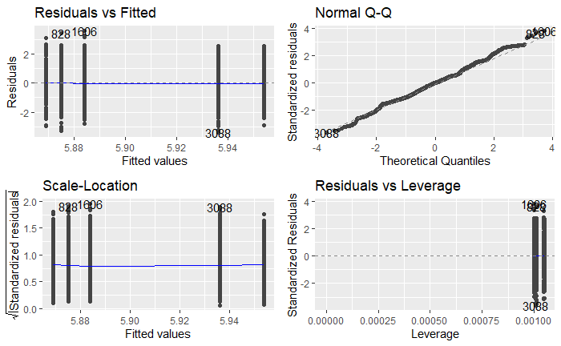

```r
autoplot(model_1c)
```

```r
summary(model_1c_alt)
```

```
Call:
lm(formula = quality ~ europe, data = white_wine_alt)

Residuals:
    Min      1Q  Median      3Q     Max
-3.3500 -0.6491  0.0109  0.5300  3.5300

Coefficients:
            Estimate Std. Error t value Pr(>|t|)
(Intercept)  5.91004    0.02105 280.758   <2e-16 ***
europeTRUE  -0.01098    0.02735  -0.401    0.688
---
Signif. codes:  0 ‘***’ 0.001 ‘**’ 0.01 ‘*’ 0.05 ‘.’ 0.1 ‘ ’ 1

Residual standard error: 0.9407 on 4896 degrees of freedom
Multiple R-squared:  3.289e-05, Adjusted R-squared:  -0.0001714
F-statistic: 0.161 on 1 and 4896 DF,  p-value: 0.6882
```

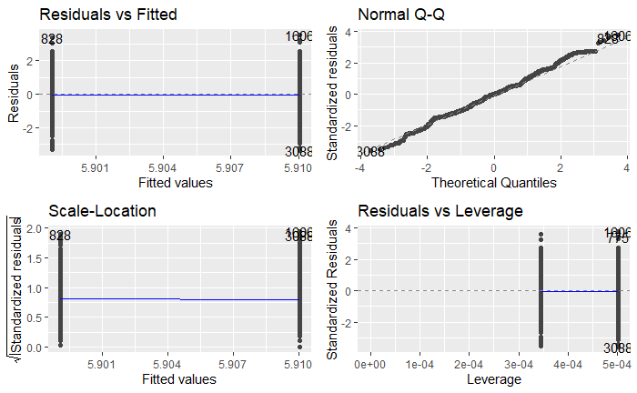

```r
autoplot(model_1c_alt)
```

```r
# neither seem significant
```

```r
model_1d <- lm(
  formula = quality ~ chlorides,
  data = white_wine_alt
)

model_1d_log <- lm(
  formula = quality ~ log_chlorides,
  data = white_wine_alt
)

summary(model_1d)
```

```
Call:
lm(formula = quality ~ chlorides, data = white_wine_alt)

Residuals:
    Min      1Q  Median      3Q     Max
-3.3853 -0.6165  0.0017  0.5394  3.4159

Coefficients:
            Estimate Std. Error t value Pr(>|t|)
(Intercept)  6.30427    0.03055  206.33   <2e-16 ***
chlorides   -8.75508    0.60243  -14.53   <2e-16 ***
---
Signif. codes:  0 ‘***’ 0.001 ‘**’ 0.01 ‘*’ 0.05 ‘.’ 0.1 ‘ ’ 1

Residual standard error: 0.921 on 4896 degrees of freedom
Multiple R-squared:  0.04135,   Adjusted R-squared:  0.04116
F-statistic: 211.2 on 1 and 4896 DF,  p-value: < 2.2e-16
```

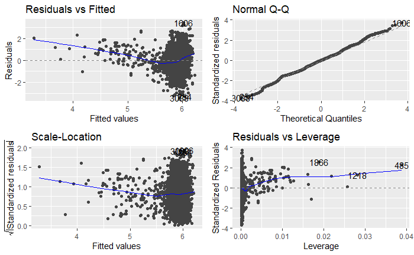

```r
autoplot(model_1d)
```

```r
summary(model_1d_log)
```

```
Call:
lm(formula = quality ~ log_chlorides, data = white_wine_alt)

Residuals:
    Min      1Q  Median      3Q     Max
-3.4369 -0.6056 -0.0043  0.5605  3.3169

Coefficients:
              Estimate Std. Error t value Pr(>|t|)
(Intercept)    3.54389    0.12395   28.59   <2e-16 ***
log_chlorides -0.74933    0.03915  -19.14   <2e-16 ***
---
Signif. codes:  0 ‘***’ 0.001 ‘**’ 0.01 ‘*’ 0.05 ‘.’ 0.1 ‘ ’ 1

Residual standard error: 0.9074 on 4896 degrees of freedom
Multiple R-squared:  0.06963,   Adjusted R-squared:  0.06944
F-statistic: 366.4 on 1 and 4896 DF,  p-value: < 2.2e-16
```

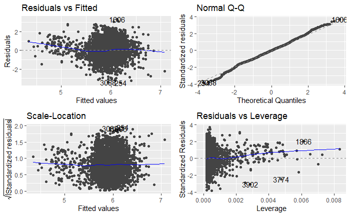

```r
autoplot(model_1d_log)
```

```r
# Not a very high R-squared
```

```r
model_1e <- lm(
  formula = quality ~ volatile_acidity,
  data = white_wine_alt
)

summary(model_1e)
```

```
Call:
lm(formula = quality ~ volatile_acidity, data = white_wine_alt)

Residuals:
    Min      1Q  Median      3Q     Max
-3.4823 -0.6262 -0.0278  0.5396  3.5041

Coefficients:
                 Estimate Std. Error t value Pr(>|t|)
(Intercept)       6.39707    0.03875  165.09   <2e-16 ***
volatile_acidity -1.77377    0.13094  -13.55   <2e-16 ***
---
Signif. codes:  0 ‘***’ 0.001 ‘**’ 0.01 ‘*’ 0.05 ‘.’ 0.1 ‘ ’ 1

Residual standard error: 0.9236 on 4896 degrees of freedom
Multiple R-squared:  0.03613,   Adjusted R-squared:  0.03593
F-statistic: 183.5 on 1 and 4896 DF,  p-value: < 2.2e-16
```

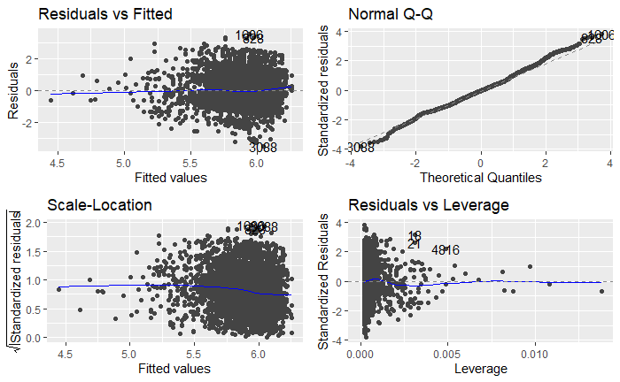

```r
autoplot(model_1e)
```

gonna go with alcohol for model 1

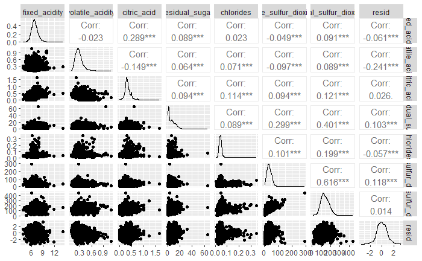

```r
# I forgot about this step, so i went back and did it, but its too late to change all the stuff i've already done

white_wine_resid <- white_wine_alt %>%
  add_residuals(model = model_1a) %>%
  select(- c(quality, alcohol))

group_1_resid <- white_wine_resid %>%
  select(!starts_with("log_")) %>%
  select(!wine_id) %>%
  select(fixed_acidity:total_sulfur_dioxide, resid)

group_2_resid <- white_wine_resid %>%
  select(!starts_with("log_")) %>%
  select(!wine_id) %>%
  select(density:resid)

ggpairs(group_1_resid)
```

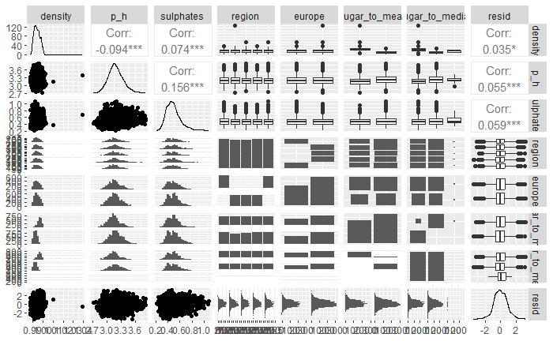

```r
ggpairs(group_2_resid)
```

```r
model_2a <- lm(
  formula = quality ~ alcohol + region,
  data = white_wine_alt
)

summary(model_2a)
```

```
Call:
lm(formula = quality ~ alcohol + region, data = white_wine_alt)

Residuals:
    Min      1Q  Median      3Q     Max
-3.4956 -0.5638 -0.0197  0.5472  3.2993

Coefficients:
              Estimate Std. Error t value Pr(>|t|)
(Intercept)   2.508635   0.107543  23.327   <2e-16 ***
alcohol       0.321349   0.009911  32.422   <2e-16 ***
regionFrance -0.006723   0.038567  -0.174   0.8616
regionItaly   0.072087   0.038586   1.868   0.0618 .
regionSpain  -0.012776   0.038245  -0.334   0.7384
regionUSA     0.029480   0.038194   0.772   0.4402
---
Signif. codes:  0 ‘***’ 0.001 ‘**’ 0.01 ‘*’ 0.05 ‘.’ 0.1 ‘ ’ 1

Residual standard error: 0.8532 on 4892 degrees of freedom
Multiple R-squared:  0.178, Adjusted R-squared:  0.1771
F-statistic: 211.8 on 5 and 4892 DF,  p-value: < 2.2e-16
```

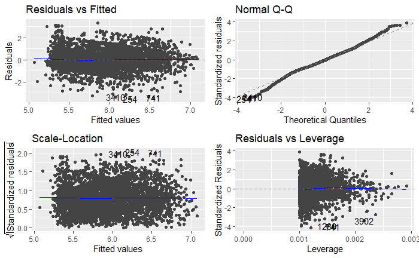

```r
autoplot(model_2a)
```

```r
model_2a_alt <- lm(
  formula = quality ~ alcohol + europe,
  data = white_wine_alt
)

summary(model_2a_alt)
```

```
Call:
lm(formula = quality ~ alcohol + europe, data = white_wine_alt)

Residuals:
    Min      1Q  Median      3Q     Max
-3.5257 -0.5620 -0.0196  0.5437  3.2847

Coefficients:
            Estimate Std. Error t value Pr(>|t|)
(Intercept) 2.522022   0.106204   23.75   <2e-16 ***
alcohol     0.321472   0.009913   32.43   <2e-16 ***
europeTRUE  0.002475   0.024822    0.10    0.921
---
Signif. codes:  0 ‘***’ 0.001 ‘**’ 0.01 ‘*’ 0.05 ‘.’ 0.1 ‘ ’ 1

Residual standard error: 0.8536 on 4895 degrees of freedom
Multiple R-squared:  0.1769,    Adjusted R-squared:  0.1765
F-statistic: 525.9 on 2 and 4895 DF,  p-value: < 2.2e-16
```

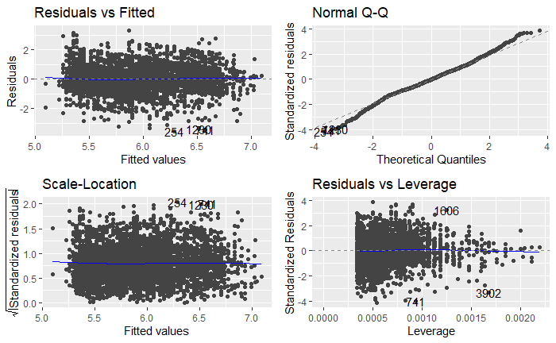

```r
autoplot(model_2a_alt)
```

```r
# ok fine region doesnt make a significant difference
```

```r
model_2b <- lm(
  formula = quality ~ alcohol + p_h,
  data = white_wine_alt
)

summary(model_2b)
```

```
Call:
lm(formula = quality ~ alcohol + p_h, data = white_wine_alt)

Residuals:
    Min      1Q  Median      3Q     Max
-3.6262 -0.5540 -0.0186  0.5461  3.2790

Coefficients:
            Estimate Std. Error t value Pr(>|t|)
(Intercept)  1.57426    0.26769   5.881 4.35e-09 ***
alcohol      0.31679    0.00997  31.773  < 2e-16 ***
p_h          0.31317    0.08126   3.854 0.000118 ***
---
Signif. codes:  0 ‘***’ 0.001 ‘**’ 0.01 ‘*’ 0.05 ‘.’ 0.1 ‘ ’ 1

Residual standard error: 0.8523 on 4895 degrees of freedom
Multiple R-squared:  0.1794,    Adjusted R-squared:  0.179
F-statistic:   535 on 2 and 4895 DF,  p-value: < 2.2e-16
```

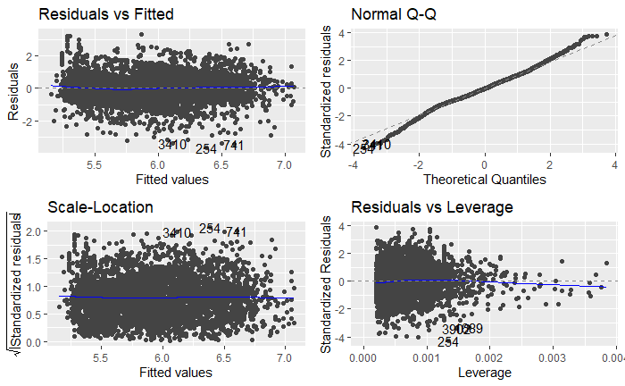

```r
autoplot(model_2b)
```

```r
anova(model_1a, model_2b)
```

```
Analysis of Variance Table

Model 1: quality ~ alcohol
Model 2: quality ~ alcohol + p_h
  Res.Df    RSS Df Sum of Sq      F    Pr(>F)
1   4896 3566.3
2   4895 3555.5  1    10.789 14.854 0.0001176 ***
---
Signif. codes:  0 ‘***’ 0.001 ‘**’ 0.01 ‘*’ 0.05 ‘.’ 0.1 ‘ ’ 1
```

```r
model_2c <- lm(
  formula = quality ~ alcohol + sugar_to_mean,
  data = white_wine_alt
)

summary(model_2c)
```

```
Call:
lm(formula = quality ~ alcohol + sugar_to_mean, data = white_wine_alt)

Residuals:
    Min      1Q  Median      3Q     Max
-3.4896 -0.5651 -0.0238  0.5500  3.2403

Coefficients:
                   Estimate Std. Error t value Pr(>|t|)
(Intercept)         2.32669    0.11043   21.07  < 2e-16 ***
alcohol             0.34824    0.01099   31.68  < 2e-16 ***
sugar_to_meanLower -0.15145    0.02724   -5.56 2.84e-08 ***
---
Signif. codes:  0 ‘***’ 0.001 ‘**’ 0.01 ‘*’ 0.05 ‘.’ 0.1 ‘ ’ 1

Residual standard error: 0.8509 on 4895 degrees of freedom
Multiple R-squared:  0.182, Adjusted R-squared:  0.1817
F-statistic: 544.7 on 2 and 4895 DF,  p-value: < 2.2e-16
```

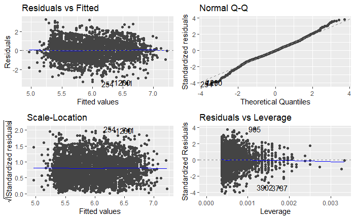

```r
autoplot(model_2c)
```

```r
anova(model_1a, model_2c)
```

```
Analysis of Variance Table

Model 1: quality ~ alcohol
Model 2: quality ~ alcohol + sugar_to_mean
  Res.Df    RSS Df Sum of Sq      F    Pr(>F)
1   4896 3566.3
2   4895 3543.9  1    22.379 30.911 2.845e-08 ***
---
Signif. codes:  0 ‘***’ 0.001 ‘**’ 0.01 ‘*’ 0.05 ‘.’ 0.1 ‘ ’ 1
```

seems to be more significant than ph. Let’s go with that

```r
model_3a <- lm(
  formula = quality ~ alcohol + sugar_to_mean + p_h,
  data = white_wine_alt
)

summary(model_3a)
```

```
Call:
lm(formula = quality ~ alcohol + sugar_to_mean + p_h, data = white_wine_alt)

Residuals:
    Min      1Q  Median      3Q     Max
-3.6099 -0.5639 -0.0239  0.5390  3.3085

Coefficients:
                   Estimate Std. Error t value Pr(>|t|)
(Intercept)         1.13908    0.27583   4.130 3.69e-05 ***
alcohol             0.34572    0.01098  31.481  < 2e-16 ***
sugar_to_meanLower -0.16954    0.02745  -6.175 7.13e-10 ***
p_h                 0.38399    0.08176   4.697 2.72e-06 ***
---
Signif. codes:  0 ‘***’ 0.001 ‘**’ 0.01 ‘*’ 0.05 ‘.’ 0.1 ‘ ’ 1

Residual standard error: 0.849 on 4894 degrees of freedom
Multiple R-squared:  0.1857,    Adjusted R-squared:  0.1852
F-statistic: 372.1 on 3 and 4894 DF,  p-value: < 2.2e-16
```

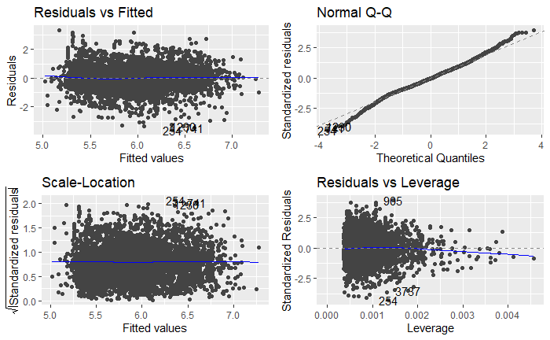

```r
autoplot(model_3a)
```

```r
anova(model_1a, model_3a)
```

```
Analysis of Variance Table

Model 1: quality ~ alcohol
Model 2: quality ~ alcohol + sugar_to_mean + p_h
  Res.Df    RSS Df Sum of Sq      F    Pr(>F)
1   4896 3566.3
2   4894 3528.0  2     38.28 26.551 3.397e-12 ***
---
Signif. codes:  0 ‘***’ 0.001 ‘**’ 0.01 ‘*’ 0.05 ‘.’ 0.1 ‘ ’ 1
```

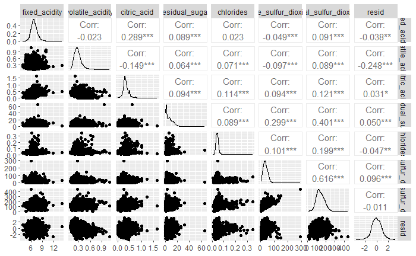

```r
white_wine_resid <- white_wine_alt %>%
  add_residuals(model = model_3a) %>%
  select(- c(quality, alcohol, sugar_to_mean, p_h, wine_id))

group_1_resid <- white_wine_resid %>%
  select(!starts_with("log_")) %>%
  select(fixed_acidity:total_sulfur_dioxide, resid)

group_2_resid <- white_wine_resid %>%
  select(!starts_with("log_")) %>%
  select(density:resid)

ggpairs(group_1_resid)
```

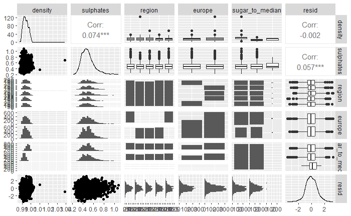

```r
ggpairs(group_2_resid)
```

volatile_acidity might make a difference

```r
model_4a <- lm(
  formula = quality ~ alcohol + sugar_to_mean + p_h + volatile_acidity,
  data = white_wine_alt
)

summary(model_4a)
```

```
Call:
lm(formula = quality ~ alcohol + sugar_to_mean + p_h + volatile_acidity,
    data = white_wine_alt)

Residuals:
    Min      1Q  Median      3Q     Max
-3.6819 -0.5472 -0.0213  0.5155  3.2117

Coefficients:
                   Estimate Std. Error t value Pr(>|t|)
(Intercept)         1.66552    0.26869   6.199 6.16e-10 ***
alcohol             0.36597    0.01069  34.224  < 2e-16 ***
sugar_to_meanLower -0.21426    0.02670  -8.025 1.26e-15 ***
p_h                 0.34500    0.07920   4.356 1.35e-05 ***
volatile_acidity   -2.12078    0.11743 -18.059  < 2e-16 ***
---
Signif. codes:  0 ‘***’ 0.001 ‘**’ 0.01 ‘*’ 0.05 ‘.’ 0.1 ‘ ’ 1

Residual standard error: 0.8222 on 4893 degrees of freedom
Multiple R-squared:  0.2366,    Adjusted R-squared:  0.236
F-statistic: 379.1 on 4 and 4893 DF,  p-value: < 2.2e-16
```

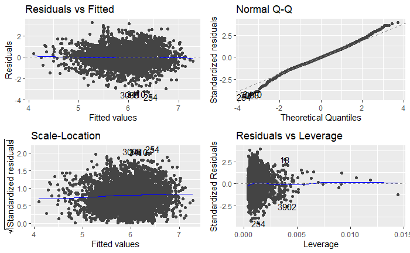

```r
autoplot(model_4a)
```

```r
anova(model_3a, model_4a)
```

```
Analysis of Variance Table

Model 1: quality ~ alcohol + sugar_to_mean + p_h
Model 2: quality ~ alcohol + sugar_to_mean + p_h + volatile_acidity
  Res.Df    RSS Df Sum of Sq      F    Pr(>F)
1   4894 3528.0
2   4893 3307.5  1    220.46 326.14 < 2.2e-16 ***
---
Signif. codes:  0 ‘***’ 0.001 ‘**’ 0.01 ‘*’ 0.05 ‘.’ 0.1 ‘ ’ 1
```

```r
broom::glance(model_3a)
```

| r.squared | adj.r.squared | sigma | statistic | p.value | df | logLik | AIC | BIC | deviance | df.residual | nobs |
| --- | --- | --- | --- | --- | --- | --- | --- | --- | --- | --- | --- |
| 0.1857125 | 0.1852133 | 0.849047 | 372.054 | 1.134736e-217 | 3 | -6146.448 | 12302.9 | 12335.38 | 3527.991 | 4894 | 4898 |

```r
print("gap")
```

```
[1] "gap"
```

```r
broom::glance(model_4a)
```

| r.squared | adj.r.squared | sigma | statistic | p.value | df | logLik | AIC | BIC | deviance | df.residual | nobs |
| --- | --- | --- | --- | --- | --- | --- | --- | --- | --- | --- | --- |
| 0.2365965 | 0.2359725 | 0.822175 | 379.1137 | 8.341749e-285 | 4 | -5988.422 | 11988.84 | 12027.82 | 3307.53 | 4893 | 4898 |

## Interpretation

It looks as if there is no one defining factor that makes a wine good - there doesn’t seem to be a single variable that contributes to quality that much. From my investigation, it seems that alcohol content, sweetness (defined by sugar content being above or below the mean), ph and the level of volatile acidity have some connection to quality. However, they only explain a small portion of the variance.

Please note, this interpretation may be flawed in that I forgot to compare to the residuals until later.